# Indicators For Upcoming Economic “Crash”

[SOURCE: U.S. Bureau of Labor Statistics - Current Employment Statistics](https://download.bls.gov/pub/time.series/ce/ce.series)

### Total # of People Employed from 2007 thru 2026 so that we can include 2008-2009 Recession Period, Pre-COVID, COVID, and recent data

Data through September 2026:

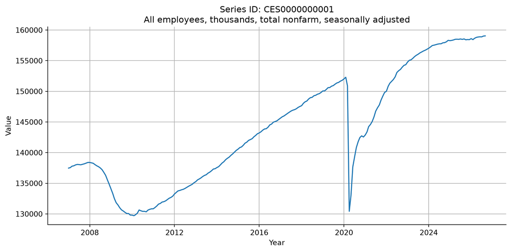

```
Last 13 recent months of data - values are in thousands
```

| series_id | year_month | year | period | value | monthly_change |
| --- | --- | --- | --- | --- | --- |
| CES0000000001 | 2025-09-01 | 2025 | M09 | 158548.0 | 76.0 |
| CES0000000001 | 2025-10-01 | 2025 | M10 | 158408.0 | -140.0 |
| CES0000000001 | 2025-11-01 | 2025 | M11 | 158449.0 | 41.0 |
| CES0000000001 | 2025-12-01 | 2025 | M12 | 158432.0 | -17.0 |
| CES0000000001 | 2026-01-01 | 2026 | M01 | 158592.0 | 160.0 |
| CES0000000001 | 2026-02-01 | 2026 | M02 | 158436.0 | -156.0 |
| CES0000000001 | 2026-03-01 | 2026 | M03 | 158650.0 | 214.0 |
| CES0000000001 | 2026-04-01 | 2026 | M04 | 158798.0 | 148.0 |
| CES0000000001 | 2026-05-01 | 2026 | M05 | 158861.0 | 63.0 |
| CES0000000001 | 2026-06-01 | 2026 | M06 | 158892.0 | 31.0 |
| CES0000000001 | 2026-07-01 | 2026 | M07 | 158882.0 | -10.0 |
| CES0000000001 | 2026-08-01 | 2026 | M08 | 159015.0 | 133.0 |
| CES0000000001 | 2026-09-01 | 2026 | M09 | 159044.0 | 29.0 |

## Now, let’s look at difference or change in total employment numbers on a monthly basis (“monthly_change”)

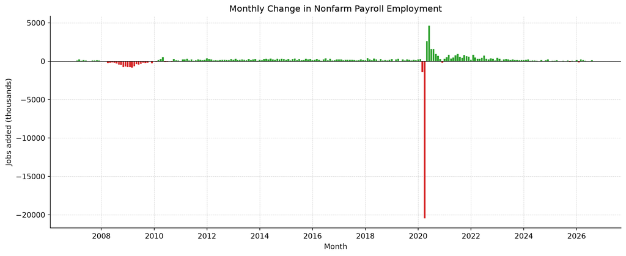

#### From above, due to the extreme values, it is hard to visually compare. So, let’s compare “normal” employment periods which exclude extreme events. So let’s combine a data set containing only 2017 thru 2019 data with another data set contaning 2024 thru 2026 data.

shape: (69, 6)

| series_id str | year_month date | year str | period str | value f64 | monthly_change f64 |
| --- | --- | --- | --- | --- | --- |
| "CES0000000001" | 2017-01-01 | "2017" | "M01" | 145628.0 | 220.0 |
| "CES0000000001" | 2017-02-01 | "2017" | "M02" | 145846.0 | 218.0 |
| "CES0000000001" | 2017-03-01 | "2017" | "M03" | 145970.0 | 124.0 |
| "CES0000000001" | 2017-04-01 | "2017" | "M04" | 146175.0 | 205.0 |
| "CES0000000001" | 2017-05-01 | "2017" | "M05" | 146380.0 | 205.0 |
| "CES0000000001" | 2017-06-01 | "2017" | "M06" | 146583.0 | 203.0 |
| "CES0000000001" | 2017-07-01 | "2017" | "M07" | 146772.0 | 189.0 |
| "CES0000000001" | 2017-08-01 | "2017" | "M08" | 146919.0 | 147.0 |
| "CES0000000001" | 2017-09-01 | "2017" | "M09" | 147008.0 | 89.0 |
| "CES0000000001" | 2017-10-01 | "2017" | "M10" | 147149.0 | 141.0 |
| "CES0000000001" | 2017-11-01 | "2017" | "M11" | 147372.0 | 223.0 |
| "CES0000000001" | 2017-12-01 | "2017" | "M12" | 147523.0 | 151.0 |
| … | … | … | … | … | … |
| "CES0000000001" | 2025-10-01 | "2025" | "M10" | 158408.0 | -140.0 |
| "CES0000000001" | 2025-11-01 | "2025" | "M11" | 158449.0 | 41.0 |
| "CES0000000001" | 2025-12-01 | "2025" | "M12" | 158432.0 | -17.0 |
| "CES0000000001" | 2026-01-01 | "2026" | "M01" | 158592.0 | 160.0 |
| "CES0000000001" | 2026-02-01 | "2026" | "M02" | 158436.0 | -156.0 |
| "CES0000000001" | 2026-03-01 | "2026" | "M03" | 158650.0 | 214.0 |
| "CES0000000001" | 2026-04-01 | "2026" | "M04" | 158798.0 | 148.0 |
| "CES0000000001" | 2026-05-01 | "2026" | "M05" | 158861.0 | 63.0 |
| "CES0000000001" | 2026-06-01 | "2026" | "M06" | 158892.0 | 31.0 |
| "CES0000000001" | 2026-07-01 | "2026" | "M07" | 158882.0 | -10.0 |
| "CES0000000001" | 2026-08-01 | "2026" | "M08" | 159015.0 | 133.0 |
| "CES0000000001" | 2026-09-01 | "2026" | "M09" | 159044.0 | 29.0 |

[interactive chart not shown]

**From above, we see it is now easier to visually compare. There was a little bit of up-tick for beginning of 2026, but in recent months, jobs added are still low compared to pre-COVID.**

### Let’s look at private sector employment

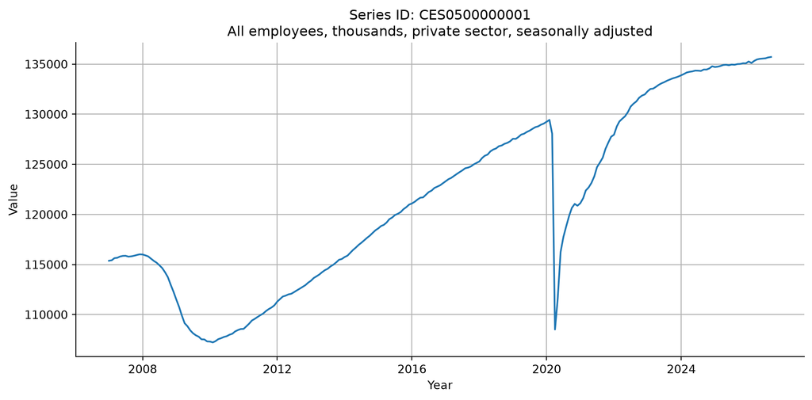

```
Last 13 recent months of data
```

| series_id | year_month | year | period | value | monthly_change |
| --- | --- | --- | --- | --- | --- |
| CES0500000001 | 2025-09-01 | 2025 | M09 | 135005.0 | 68.0 |
| CES0500000001 | 2025-10-01 | 2025 | M10 | 135018.0 | 13.0 |
| CES0500000001 | 2025-11-01 | 2025 | M11 | 135090.0 | 72.0 |
| CES0500000001 | 2025-12-01 | 2025 | M12 | 135083.0 | -7.0 |
| CES0500000001 | 2026-01-01 | 2026 | M01 | 135263.0 | 180.0 |
| CES0500000001 | 2026-02-01 | 2026 | M02 | 135115.0 | -148.0 |
| CES0500000001 | 2026-03-01 | 2026 | M03 | 135317.0 | 202.0 |
| CES0500000001 | 2026-04-01 | 2026 | M04 | 135467.0 | 150.0 |
| CES0500000001 | 2026-05-01 | 2026 | M05 | 135528.0 | 61.0 |
| CES0500000001 | 2026-06-01 | 2026 | M06 | 135554.0 | 26.0 |
| CES0500000001 | 2026-07-01 | 2026 | M07 | 135582.0 | 28.0 |
| CES0500000001 | 2026-08-01 | 2026 | M08 | 135671.0 | 89.0 |
| CES0500000001 | 2026-09-01 | 2026 | M09 | 135717.0 | 46.0 |

[interactive chart not shown]

#### Average of monthly change from 2017 thru 2019 of all non-farm employment:

```python
(
    GT(
        df_all
        .filter(
            pl.col("year").is_in(["2017","2018","2019"])
        )
        .select(
            pl.col("monthly_change").mean().alias("avg_value")
        )
    )
    .fmt_number(columns="avg_value", decimals=2)
    .cols_align(align="center")
    .show()
)
```

| avg_value |
| --- |
| 177.39 |

#### Average of monthly change from 2024 thru 2026 of all non-farm employment:

```python
(
    GT(
        df_all
        .filter(
            pl.col("year").is_in(["2024","2025","2026"])
        )
        .select(
            pl.col("monthly_change").mean().alias("avg_value")
        )
    )
    .fmt_number(columns="avg_value", decimals=2)
    .cols_align(align="center")
    .show()
)
```

| avg_value |
| --- |
| 66.27 |

On average, during the few years before COVID, 177 thousand jobs were added. From 2024 thru 2026, only 66 thousand jobs were added on average.

#### Average of monthly change from 2017 thru 2019 of all private sector employment:

```python
(
    GT(
        df_private
        .filter(
            pl.col("year").is_in(["2017","2018","2019"])
        )
        .select(
            pl.col("monthly_change").mean().alias("avg_value")
        )
    )
    .fmt_number(columns="avg_value", decimals=2)
    .cols_align(align="center")
    .show()
)
```

| avg_value |
| --- |
| 165.67 |

#### Average of monthly change from 2024 thru 2026 of all private sector employment:

```python
(
    GT(
        df_private
        .filter(
            pl.col("year").is_in(["2024","2025","2026"])
        )
        .select(
            pl.col("monthly_change").mean().alias("avg_value")
        )
    )
    .fmt_number(columns="avg_value", decimals=2)
    .cols_align(align="center")
    .show()
)
```

| avg_value |
| --- |
| 59.12 |

On average, during the few years before COVID, 166 thousand jobs were added. From 2024 thru 2026, only 59 thousand jobs were added on average.

## Let’s take population into account of employment-eligible persons (16 years old and over) using series ID “LNS12300000”

[SOURCE: U.S. Bureau of Labor Statistics - National Unemployment](https://download.bls.gov/pub/time.series/ln/ln.series)

Data through September 2026:

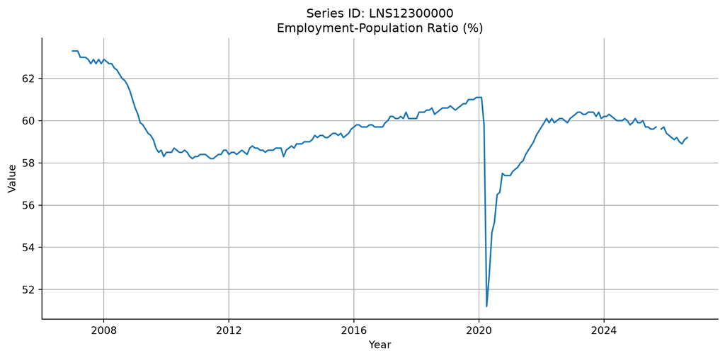

```
Last 5 recent months of data
```

| series_id | year_month | year | period | value |
| --- | --- | --- | --- | --- |
| LNS12300000 | 2026-05-01 | 2026 | M05 | 59.2 |
| LNS12300000 | 2026-06-01 | 2026 | M06 | 59.0 |
| LNS12300000 | 2026-07-01 | 2026 | M07 | 58.9 |
| LNS12300000 | 2026-08-01 | 2026 | M08 | 59.1 |
| LNS12300000 | 2026-09-01 | 2026 | M09 | 59.2 |

When taking into account population level, we are at a downward trend. Pre-COVID, the trend was upwards.

# Let’s look at a few more metrics

## Layoffs and Discharges

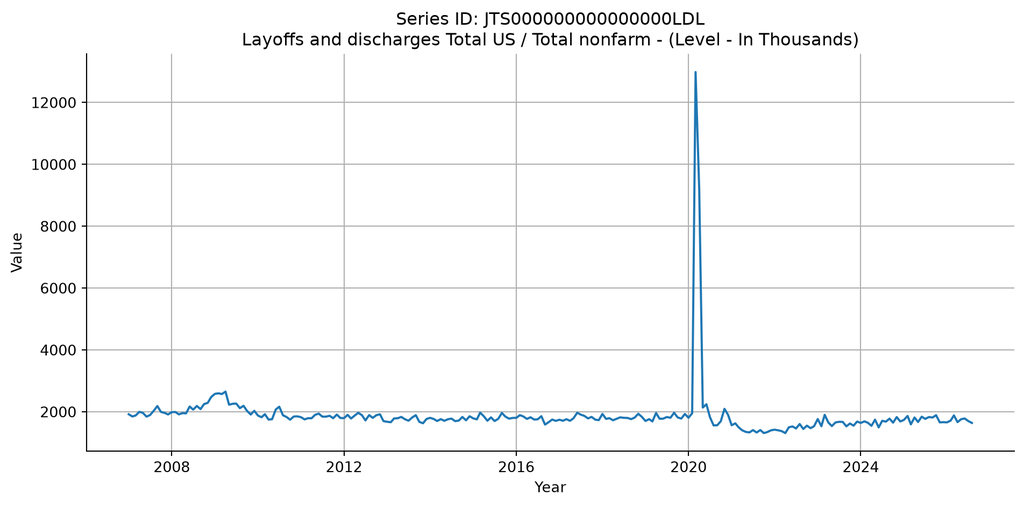

## Hires

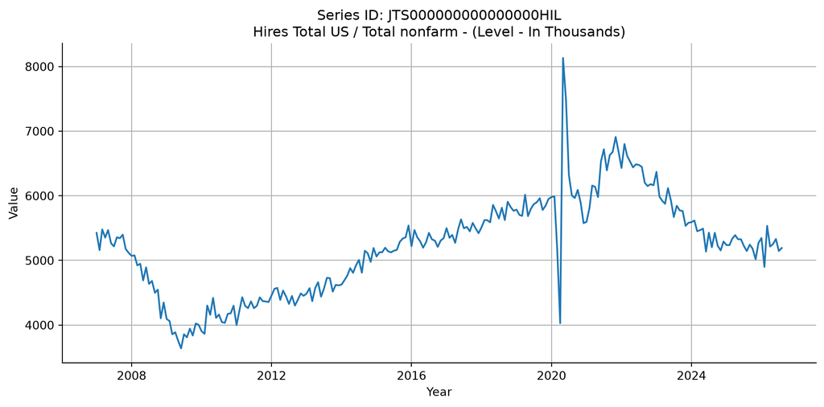

## Job Openings

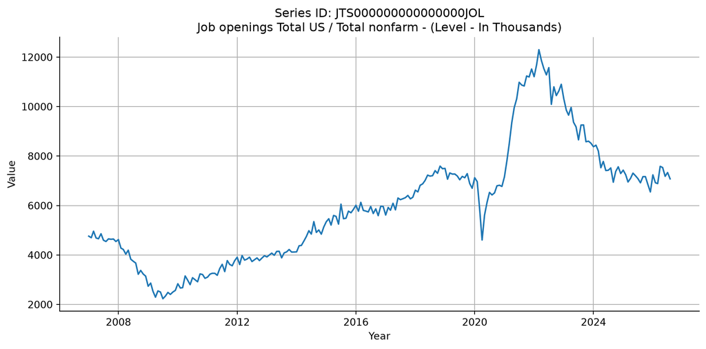

Layoffs and discharges don’t look too alarming, but the number of hires and job openings are concerning.